# Project 4 Causal Inference

Group 7

Daizy Lam, Qiao Li, Chuanchuan Liu, Yingyao Wu, Serena Yuan

# Propensity Score

Step 0: Set up the environment

Step 1: Load Data

```r
lowDim <- read.csv("../data/lowDim_dataset.csv")
highDim <- read.csv("../data/highDim_dataset.csv")
```

```r
# Split into A, x and y
#highDim_dataset
# highA<-highDim$A
# highY<-highDim$Y
# highX<-highDim%>% select(-Y, -A) %>% as.matrix
#
# #lowDim_dataset
# lowA<-lowDim$A
# lowY<-lowDim$Y
# lowX<-lowDim%>% select(-Y, -A) %>% as.matrix
```

step 2: L2 Penalized Logistic Regression

To avoid overfitting of the logistic regression model, we introduce regularization term to decrease the model variance in the loss function Q

```r
propensity_score <- function(data){
  set.seed(0)
  start_time <- Sys.time()
  A<-data$A
  Y<-data$Y
  #X<-data%>% select(-Y, -A) %>% as.matrix


  glm <- cv.glmnet(data.matrix(data[,-c(1,2)]), A, family = "binomial", alpha = 0)

  p_score <- predict(glm$glmnet.fit,
                      s = glm$lambda.min,
                      newx = data.matrix(data[,-c(1,2)]),
                      type = "response")

  end_time <- Sys.time()
  running_time = end_time - start_time
  #cat("Time for Propensity Matching Low_Dim is:", running_time, "seconds.")
  return(p_score)
}
```

# Stratification

Stratification (sometimes referred to as subclassification) is commonly used in observational studies to control for systematic differences between the control and treated groups. This technique consists of grouping subjects into strata determined by observed background characteristics. (D’Agostino, 1998)

We will estimate the Average Treatment Effect (ATE) using stratification based on L2 penalized Logistic Regression propensity scores. The algorithm will be based on the following equation:

$$\hat \Delta_S = \sum_{j=1}^K \frac{N_j}{N} \{N_{1j}^{-1} \sum_{i=1}^N T_i Y_i I(\hat e_i \in \hat Q_j) - N_{0j}^{-1} \sum_{i=1}^N (1-T_i) Y_i I(\hat e_i \in \hat Q_j)\}$$

where K is the number of strata, $N_j$ is the number of individuals in stratum j, $N_{1j}$ is the number of “treated” individuals in stratum j and $N_{0j}$ is the number of “controlled” individuals in stratum j. $\hat Q_j = (\hat q_{j-1}, q_j]$ is the interval from (j-1)th sample quantile to jth sample quantile of the estimated propensity scores. (Lunceford and Davidian, 2004)

## L2 Logistic Regression Propensity Score

```r
ps_high = propensity_score(highDim)
ps_low = propensity_score(lowDim)
```

## Estimate Average Treatment Effect (ATE)

We first determine the number of strata K and create equally spaced intervals starting from 0 to 1. In the example below we are using K = 5, and the resulting intervals would be (0, 0.2, 0.4, 0.6, 0.8, 1).

```r
K = 5 # number of strata
q = seq(0, 1, by = 1/K) # sample quantile
```

Then we form K strata according to the sample quantiles of the $\hat e_i$ (estimated propensity scores), i = 1, …, N (sample size/number of observations), where the jth sample quantile $\hat q_j$, for j = 1, …, K, is such that the proportion of $\hat e_i \leq \hat q_j$ is roughly j/K, $\hat q_0 = 0$ and $\hat q_K = 1$. (Lunceford and Davidian, 2004)

Within each stratum, we subset the observations for the specific strata, i.e. observations whose propensity scores fall in the interval $(q_{j-1},q_j]$. We then split the subsetted data set into “treated” and “controlled” groups using the binary treatment indicator ‘A’. For each group within the stratum, we calculate the summation over the multiplication of treatment indicator ‘A’ and outcome ‘Y’, and divide the sum by the number of individuals for each group.

Then the estimated ATE would be the summation over all K strata of the weighted sum of the difference of “treated” and “controlled” groups as described above.

```r
stratification = function(df, ps){
  tm_start = Sys.time()
  # split into K strata
  stratum = rep(NA, length(q))
  for (i in 1:length(q)){
    stratum[i] = quantile(ps, q[i])
  }
  # ATE
  ate_strata = rep(NA, K)
  for (j in 1:K){
    # select observations whose propensity score is within (q_{j-1},q_j]
    curr.obs = df[which(stratum[j] < ps & ps <= stratum[j+1]),]

    # subset/select treatment and control groups
    treatment_strata = curr.obs[curr.obs$A == 1,]
    control_strata = curr.obs[curr.obs$A == 0,]

    # calculate sum within stratum
    treatment_sum = sum(treatment_strata$A * treatment_strata$Y) / nrow(treatment_strata)
    control_sum = sum((1 - control_strata$A) * control_strata$Y) / nrow(control_strata)
    ate_strata[j] = (nrow(curr.obs)/nrow(df)) * (treatment_sum - control_sum)
  }
  tm_end = Sys.time()
  cat("The estimated ATE is", sum(ate_strata), "\n")
  cat("Run time is", (tm_end - tm_start), "s")
  return(list(sum(ate_strata), (tm_end - tm_start)))
}
```

### High Dimension Data Set

```r
strata_high = stratification(highDim, ps_high)
```

```
The estimated ATE is -57.93487
Run time is 0.0867362 s
```

### Low Dimension Data Set

```r
strata_low = stratification(lowDim, ps_low)
```

## Performance

- True ATE for High Dimension Data Set: -54.8558
- True ATE for Low Dimension Data Set: 2.0901

```r
true_ate_high = -54.8558
true_ate_low = 2.0901
cat("Performance for High Dimension Data is", abs(true_ate_high - strata_high[[1]]), "\n")
```

```
Performance for High Dimension Data is 3.079069
```

```r
cat("Performance for Low Dimension Data is", abs(true_ate_low - strata_low[[1]]))
```

```
Performance for Low Dimension Data is 0.2864389
```

```r
res = matrix(rep(NA,4), ncol = 2)
colnames(res) = c("Performance", "Computational Efficiency")
rownames(res) = c("High Dimension", "Low Dimension")
res[1,1] = abs(true_ate_high - strata_high[[1]])
res[1,2] = abs(true_ate_low - strata_low[[1]])
res[2,1] = strata_high[[2]]
res[2,2] = strata_low[[2]]
res
```

```
               Performance Computational Efficiency
High Dimension   3.0790690              0.286438938
Low Dimension    0.1085849              0.008121967
```

# Regression Estimate with no need of propensity score

### This algorithm builds regression model fit to control groups and treatment groups, and then makes predictions based on the model in order to calculate ATE.

## Load Data

```r
lowDim_df <- read.csv('../data/lowDim_dataset.csv')
highDim_df <- read.csv('../data/highDim_dataset.csv')
```

## Algorithm

```r
Regression_Estimation <- function(df){

  start_time <- Sys.time()

  # regression model for control groups (A=0)
  model0 <- glm(formula=Y~., data=subset(df[which(df$A==0),],select=-c(A)))
  # regression model for treatment groups (A=1)
  model1 <- glm(formula=Y~., data=subset(df[which(df$A==1),],select=-c(A)))

  X = subset(df, select=-c(Y,A)) #input data for prediction

  #prediction using model0
  Y0 <- predict(model0, newdata=X)
  #prediction using model1
  Y1 <- predict(model1, newdata=X)

  # calculate ATE
  ATE <- mean(Y1-Y0)

  # calculate running time
  end_time <- Sys.time()
  running_time <- end_time - start_time

  return (list(ATE=ATE, running_time=running_time))
}
```

## summarize

- ATE

```r
Regression_Estimation(lowDim_df)
```

```
$ATE
[1] 2.125138

$running_time
Time difference of 0.06135011 secs
```

- Running Time

```r
running_time_low <- Regression_Estimation(lowDim_df)$running_time
running_time_high <- Regression_Estimation(highDim_df)$running_time
cat("Running Time for Low Dimension Data is", running_time_low, "sec.","\n")
cat("Running Time for High Dimension Data is", running_time_high, "sec.")
```

- Performance

```r
true_ate_low = 2.0901
true_ate_high = -54.8558
performance_low <- abs(true_ate_low - calc_ate_low)
performance_high <- abs(true_ate_high - calc_ate_high)
cat("Performance for Low Dimension Data is", performance_low, "\n" )
cat("Performance for High Dimension Data is", performance_high)
```

- Result

```r
RE <- matrix(c(calc_ate_high,calc_ate_low,running_time_high,running_time_low,performance_high,performance_low), ncol = 3, nrow=2)
colnames(RE) = c("ATE","Computational Efficiency","Performance")
rownames(RE) = c("High Dimension", "Low Dimension")
RE
```

# Weighted Regression

```r
df_ld <- lowDim %>% mutate(A = factor(A))
df_hd <- highDim %>% mutate(A = factor(A))
```

```r
#assign variables for data frame
# X_low <- df_ld %>% select(-Y, -A) %>% as.matrix
# A_low <- df_ld %>% select(A) %>% as.matrix
# X_high <- df_hd %>% select(-Y, -A) %>% as.matrix
# A_high <- df_hd %>% select(A) %>% as.matrix
X_low <- data.matrix(df_ld[,-c(1,2)])
A_low <- data.matrix(df_ld[,2])
X_high <- data.matrix(df_hd[,-c(1,2)])
A_high <- data.matrix(df_hd[,2])

#running cv with L2
#cv_L2_low <- cv.glmnet(X_low, A_low, family = "binomial", alpha = 0)
#cv_L2_high <- cv.glmnet(X_high, A_high, family = "binomial", alpha = 0)
```

```r
Weighted_Regression <- function(X,A,df,cv, threshold){
  start_time <- Sys.time()
  #L2 to get propensity score -low
  #L2 <- glmnet(X, A, family = "binomial",
  #               alpha = 0, lambda = cv$lambda.min)
  #calculate propensity score
  #propensity_score <- predict(L2, X, type = "response")

  # Finding weights
  t<- as.numeric(A)
  wt<- t/(propensity_score(df)) + (1-t)/(1-propensity_score(df))

  # Estimate linear regression
  Y <- df$Y
  model<- lm(Y~., data = df)
  feature_z <- summary(model)$coef[,4][-c(1:2)]<threshold
  Z <- as.data.frame(cbind(A,X[,feature_z]))
  Z<-sapply(Z, as.numeric)

  #Weighted Regression
  weighted_reg <- lm(Y ~ Z, weights = wt)

  #coef of T is an estimate for ATE
  ATE<- coef(weighted_reg)[2]
  end_time <- Sys.time()
  running_time <- end_time - start_time
  cat("The estimated ATE is", ATE, "\n")
  cat("Run time is", running_time , "s")
  return (list(ATE=ATE, running_time=running_time))

}
```

# Different Thresholds for Best ATE

```r
thresholds <- c(0.1, 0.05, 0.02, 0.01, 0.005)

ate_scores_low <- c()
ate_scores_high <- c()

true_ate_high = -54.8558
true_ate_low = 2.0901

for (t in thresholds) {
  wreg_low = Weighted_Regression(X_low, A_low, df_ld, cv_L2_low, t)
  wreg_high = Weighted_Regression(X_high, A_high, df_hd, cv_L2_high, t)
  diff_low = abs(true_ate_low - wreg_low[[1]])
  diff_high = abs(true_ate_high - wreg_high[[1]])
  append(ate_scores_low, diff_low)
  append(ate_scores_high, diff_high)
}
```

Set threshold to the optimal value:

```r
opt_low <- which.min(ate_scores_low)
opt_high <- which.min(ate_scores_high)
threshold_low <- thresholds[opt_low]
threshold_high <- thresholds[opt_high]
```

```r
Weighted_Regression_low = Weighted_Regression(X_low,A_low,df_ld,cv_L2_low, threshold_low)
```

```r
Weighted_Regression_high = Weighted_Regression(X_high,A_high,df_hd,cv_L2_high, threshold_high)
```

```r
high = matrix(rep(NA,6), nrow = 3)
rownames(high) = c("Stratification", "Regression Estimate", "Weighted Regression")
colnames(high) = c("Performance", "Computational Efficiency")
# stratification
high[1,1] = abs(true_ate_high - strata_high[[1]])
high[1,2] = strata_high[[2]]
# regression estimate
# weighted regression
high
```

```
                    Performance Computational Efficiency
Stratification         3.079069                0.1085849
Regression Estimate          NA                       NA
Weighted Regression          NA                       NA
```

```r
low = matrix(rep(NA,6), nrow = 3)
rownames(low) = c("Stratification", "Regression Estimate", "Weighted Regression")
colnames(low) = c("Performance", "Computational Efficiency")
# stratification
low[1,1] = abs(true_ate_low - strata_low[[1]])
low[1,2] = strata_low[[2]]
# regression estimate
# weighted regression
low
```

```
                    Performance Computational Efficiency
Stratification        0.2864389              0.008121967
Regression Estimate          NA                       NA
Weighted Regression          NA                       NA
```

# Model Comparison

Performance: absolute error of the true and estimated ATE

Computational Efficiency: run time in seconds

**High Dimension Dataset**

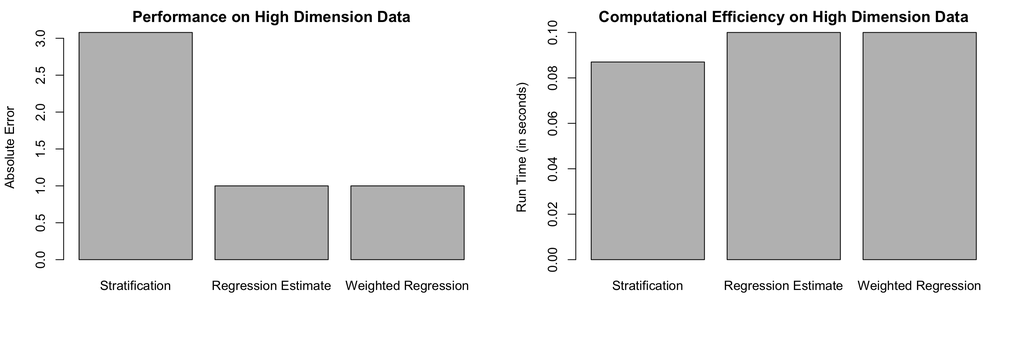

```r
high_perf = data.frame(Model = c("Stratification", "Regression Estimate", "Weighted Regression"),
                       Performance = c(round(abs(true_ate_high - strata_high[[1]]), 3), 1, 1))
high_time = data.frame(Model = c("Stratification", "Regression Estimate", "Weighted Regression"),
                       Time = c(as.numeric(round(strata_high[[2]], 3)), 0.1, 0.1))

# hp = ggplot(high_perf, aes(x = Model, y = Performance)) +
#   geom_bar(stat = "identity", fill = "light blue") +
#   geom_text(aes(label=Performance), vjust = -0.5, size = 3.5) +
#   labs(title = "Performance on High Dimension Data", y = "Absolute Error") +
#   #ylim(c(0,5)) +
#   theme_clean()
# ht = ggplot(high_time, aes(x = Model, y = Time)) +
#   geom_bar(stat = "identity", fill = "light blue") +
#   geom_text(aes(label=Time), vjust = -0.5, size = 3.5) +
#   labs(title = "Computational Efficiency on High Dimension Data", y = "Run Time (in seconds)") +
#   #ylim(c(0,0.2)) +
#   theme_clean()
# grid.arrange(hp, ht, nrow=2)

par(mfrow = c(1,2))
barplot(high_perf$Performance,
     main = "Performance on High Dimension Data",
     names.arg = high_perf$Model,
     ylab = "Absolute Error")
barplot(high_time$Time,
     main = "Computational Efficiency on High Dimension Data",
     names.arg = high_perf$Model,
     ylab = "Run Time (in seconds)")
```

**Low DimensionDataset**

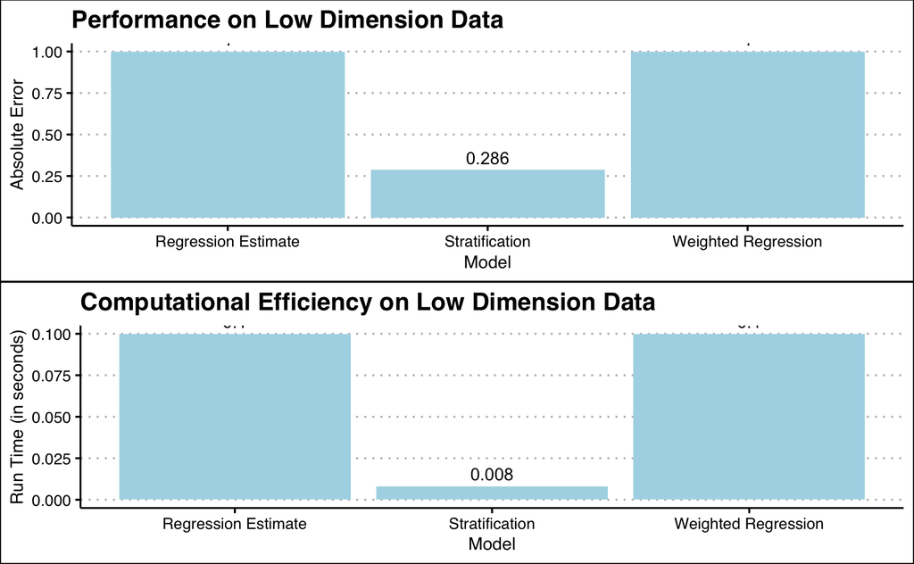

```r
low_perf = data.frame(Model = c("Stratification", "Regression Estimate", "Weighted Regression"),
                       Performance = c(round(abs(true_ate_low - strata_low[[1]]), 3), 1, 1))
low_time = data.frame(Model = c("Stratification", "Regression Estimate", "Weighted Regression"),
                       Time = c(as.numeric(round(strata_low[[2]], 3)), 0.1, 0.1))

lp = ggplot(low_perf, aes(x = Model, y = Performance)) +
  geom_bar(stat = "identity", fill = "light blue") +
  geom_text(aes(label=Performance), vjust = -0.5, size = 3.5) +
  labs(title = "Performance on Low Dimension Data", y = "Absolute Error") +
  #ylim(c(0,1)) +
  theme_clean()
lt = ggplot(low_time, aes(x = Model, y = Time)) +
  geom_bar(stat = "identity", fill = "light blue") +
  geom_text(aes(label=Time), vjust = -0.5, size = 3.5) +
  labs(title = "Computational Efficiency on Low Dimension Data", y = "Run Time (in seconds)") +
  #ylim(c(0,0.2)) +
  theme_clean()
grid.arrange(lp, lt, nrow=2)
```

```r
high_perf = data.frame(Model = c("Stratification", "Regression Estimate", "Weighted Regression"),
                       Performance = c(round(abs(true_ate_high - strata_high[[1]]), 3), 1, 1))
high_time = data.frame(Model = c("Stratification", "Regression Estimate", "Weighted Regression"),
                       Time = c(as.numeric(round(strata_high[[2]], 3)), 0.1, 0.1))

hp = ggplot(high_perf, aes(x = Model, y = Performance)) +
  geom_bar(stat = "identity", fill = "light blue") +
  geom_text(aes(label=Performance), vjust = -0.5, size = 3.5) +
  labs(title = "Performance on High Dimension Data", y = "Absolute Error") +
  #ylim(c(0,5)) +
  theme_clean()
ht = ggplot(high_time, aes(x = Model, y = Time)) +
  geom_bar(stat = "identity", fill = "light blue") +
  geom_text(aes(label=Time), vjust = -0.5, size = 3.5) +
  labs(title = "Computational Efficiency on High Dimension Data", y = "Run Time (in seconds)") +
  #ylim(c(0,0.2)) +
  theme_clean()
grid.arrange(hp, ht, nrow=2)

# par(mfrow = c(1,2))
# barplot(high_perf$Performance,
#      main = "Performance on High Dimension Data",
#      names.arg = high_perf$Model,
#      ylab = "Absolute Error")
# barplot(high_time$Time,
#      main = "Computational Efficiency on High Dimension Data",
#      names.arg = high_perf$Model,
#      ylab = "Run Time (in seconds)")
```

```r
low_perf = data.frame(Model = c("Stratification", "Regression Estimate", "Weighted Regression"),
                       Performance = c(round(abs(true_ate_low - strata_low[[1]]), 3), 1, 1))
low_time = data.frame(Model = c("Stratification", "Regression Estimate", "Weighted Regression"),
                       Time = c(as.numeric(round(strata_low[[2]], 3)), 0.1, 0.1))

lp = ggplot(low_perf, aes(x = Model, y = Performance)) +
  geom_bar(stat = "identity", fill = "light blue") +
  geom_text(aes(label=Performance), vjust = -0.5, size = 3.5) +
  labs(title = "Performance on Low Dimension Data", y = "Absolute Error") +
  #ylim(c(0,1)) +
  theme_clean()
lt = ggplot(low_time, aes(x = Model, y = Time)) +
  geom_bar(stat = "identity", fill = "light blue") +
  geom_text(aes(label=Time), vjust = -0.5, size = 3.5) +
  labs(title = "Computational Efficiency on Low Dimension Data", y = "Run Time (in seconds)") +
  #ylim(c(0,0.2)) +
  theme_clean()
lp
lt
#grid.arrange(lp, lt, nrow=2)
```

# References

D’Agostino, R. B. (1998). Propensity score methods for bias reduction in the comparison of a treatment to a non-randomized control group. Statistics in Medicine, 17(19), 2265-2281. doi:10.1002/(sici)1097-0258(19981015)17:193.0.co;2-b

Lunceford, J. K.; Davidian, M. (2004). Stratification and weighting via the propensity score in estimation of causal treatment effects: A comparative study. Statistics in Medicine, 23(19), 2937-2960. doi:10.1002/sim.1903